# Final_Project_Master

### Import necessary libraries:

```r
library(dplyr)
library(ggplot2)
library(ggmap)
library(readr)
library(zoo)
library(wordcloud)
```

## Introduction

- Topic
- Questions (.rmd file)
- Contriutions by teammates
- Yelp Dataset Challenge

## Description of Data

- Dataset structure
- Challenges
- Initial analysis
- Relationship between tables
- Type of variables

## Analysis of Data Quality

- How we narrowed it down?
  - distribution of entries by city
  - focus on restaurants
  - ambiguous/meaningless categories (could also discuss under next question)
- What were the problems with the data?
  - null values on neighborhood
  - mispelled city names
  - multiple cuisines per restaurant

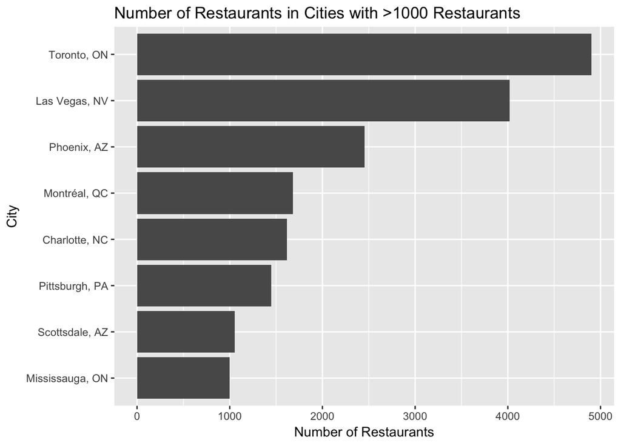

```r
# read in file with number of restaurants in each city by cuisine
# note: the SQL query for this file included only a particular set of cuisines
restaurants_by_cuisine <- read_csv("~/EDAV_project/Data/number of restaurants by cuisine.csv")

# concatenate city and state columns into one column called location
restaurants_by_cuisine <- mutate(restaurants_by_cuisine, location=paste0(city,", ",state)) %>% subset(select=c(5,1:4))

# get number of restaurants for each city
r_by_city <- restaurants_by_cuisine %>% group_by(location) %>%
                    summarize(number= sum(NumberOfRestaurants))

r_by_city_filter <- r_by_city %>% filter(number > 1000)

ggplot(r_by_city_filter, aes(x = reorder(location, number), y = number)) + geom_col() + coord_flip() + ggtitle("Number of Restaurants in Cities with >1000 Restaurants") + xlab("City") + ylab("Number of Restaurants")
```

```r
# Calculated weighted gini index for each city (measure of both diversity and quantity of restaurants in a city)

# compute percent of restaurants in each location and category
num_cuisines <- restaurants_by_cuisine %>% group_by(location,category) %>% summarise(count = sum(NumberOfRestaurants, na.rm = TRUE)) %>% mutate(perc = round(count/sum(count),4))

gini <- function(x, na.rm = TRUE) {
  index <- 1 - sum(x**2)
  return(index)
}

# calculate gini index
num_cuisines <- num_cuisines %>% group_by(location) %>% summarise(gini = gini(perc))

num_cuisines <- num_cuisines[order(-num_cuisines$gini),]
head(num_cuisines, 10)
```

```
## # A tibble: 10 x 2
##    location         gini
##    <chr>           <dbl>
##  1 Toronto, ON     0.923
##  2 Mississauga, ON 0.919
##  3 Edinburgh, MLN  0.913
##  4 Ajax, ON        0.911
##  5 Pickering, ON   0.909
##  6 Vaughan, ON     0.906
##  7 Montréal, QC    0.904
##  8 North York, ON  0.903
##  9 Oakville, ON    0.899
## 10 Brossard, QC    0.899
```

```r
# calculate weighted gini index
weighted_gini_city <- plyr::join(r_by_city, num_cuisines, by="location")
weighted_gini_city <- mutate(weighted_gini_city, weighted_gini = gini*number/sum(number))

weighted_gini_city <- weighted_gini_city[order(-weighted_gini_city$weighted_gini),]

head(weighted_gini_city, 10)
```

```
##            location number      gini weighted_gini
## 568     Toronto, ON   4903 0.9225066    0.12645167
## 250   Las Vegas, NV   4020 0.8753205    0.09837537
## 414     Phoenix, AZ   2454 0.8401270    0.05763850
## 334    Montréal, QC   1681 0.9039136    0.04248032
## 77    Charlotte, NC   1615 0.8607311    0.03886272
## 419  Pittsburgh, PA   1449 0.8556579    0.03466265
## 320 Mississauga, ON   1001 0.9186229    0.02570778
## 507  Scottsdale, AZ   1056 0.8302322    0.02451075
## 89    Cleveland, OH    827 0.8412700    0.01945065
## 277     Madison, WI    693 0.8692630    0.01684138
```

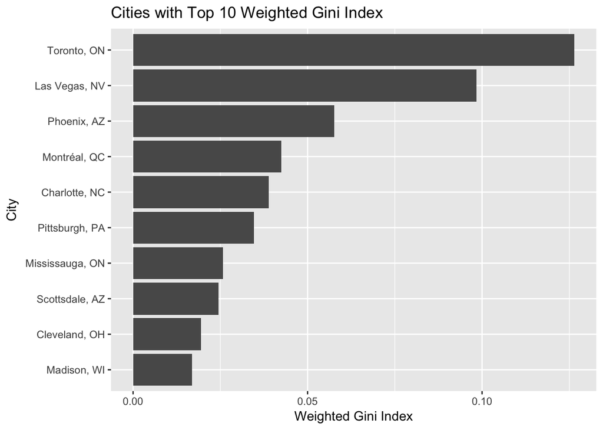

```r
# get cities with top 10 weighted gini index
weighted_gini_city_filter <- weighted_gini_city %>% top_n(10, weighted_gini)

ggplot(weighted_gini_city_filter, aes(x = reorder(location, weighted_gini), y = weighted_gini)) + geom_col() + coord_flip() + ggtitle("Cities with Top 10 Weighted Gini Index") + xlab("City") + ylab("Weighted Gini Index")
```

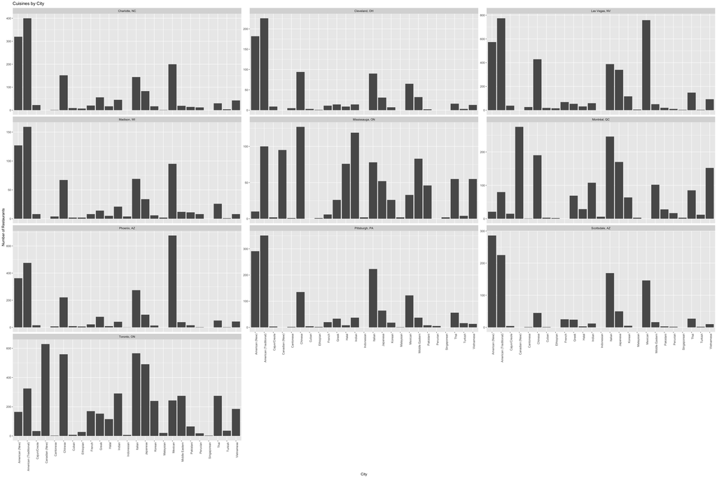

```r
# visualizing diversity of restaurants in cities with top 10 weighted gini index

top_10_cities <- unique(weighted_gini_city_filter$location)

r_by_city_cuisine <- filter(restaurants_by_cuisine, location %in% top_10_cities)

#refactoring location columns
r_by_city_cuisine$location <- factor(r_by_city_cuisine$location)

ggplot(r_by_city_cuisine, aes(x=category, y=NumberOfRestaurants)) + geom_col() + facet_wrap(~location, scales="free_y", ncol=3) + theme(axis.text.x = element_text(angle=90, hjust=1)) + ggtitle("Cuisines by City") + xlab("City") + ylab("Number of Restaurants")
```

## Main Analysis (Exploratory Data Analysis)

- Which areas are most diverse?
- How are the restaurants distributed across neighborhoods?
- What is the distribution of different cuisines in Toronto?
- How does sentiment differ for good and bad reviews?
- What is the impact of yelp elite reviews on overall review sentiment (for a popular restaurant?
- What is the distribution of the ratings by cuisine?
- What is the distribution of sentiment by cuisine?
- What is the distribution of number of check-ins by cuisine?
- What is the relationship between ratings, sentiment, and number of checkins (parallel coordinate plot)?